# Project 1: Wrangling, Exploration, Visualization

SDS322E

## Data Wrangling, Exploration, Visualization

### Nelly Akhmadikina na24752

#### Introduction

I chose 3 data sets for my project. “pop1” is statistics on population of LGBT individuals in each US state including some territories. This dataset was take from the Movement Advancement Project (MAP) at https://www.lgbtmap.org/equality-maps/lgbt_populations. The variables I am using from this dataset are Total adult population (totaladpop), the LGBT Adult population(lgbtadpop), the LGBT population density(lgbtpopdensity), the Percent of Same-Sex individuals raising kids(percentindivkids), and the Percent of Same-Sex couples raising kids (percentcoupleskids). “policy1” is data on policies regarding the LGBT community. This data set includes the Sexual Orientation Policy tallies (SOpolicy) and Gender Identity Policy tallies (GIpolicy) that the Movement Advancement Project assigns to each states based on it helpful or harmful policies that are in place. The total of those two tallies is shown as Overall Tally (overallpolicy) . I will not be using any other variables from this dataset. This data is found on https://www.lgbtmap.org/equality-maps/. My third dataset “marriage1” is found on https://www.pewforum.org/religious-landscape-study/compare/views-about-same-sex-marriage/by/state/. It is from the Pew Research Center. This was a 2014 survey on Views about same-sex marriage by state. This dataset includes the percent who Favor(favormarriage), Oppose (opposemarriage), and Don’t Know (dkmarriage), as well as the sample size of the survey (marriagesample). I will not be using the sample size. I am interested in this data because I like studying statistics on the LGBT community. I wish to go into the public health sector to health the LGBT community. The datset includes District of Columbia. I keep it in during most calculations, but I remove it when grouping by region.

```r
library(tidyverse)
library(knitr)
library(kableExtra)
library(gt)
pop1 <- read_csv("LMS1.csv")
marriage1 <- read_csv("LGBT MAP - Sheet3.csv")
policy1 <- read_csv("LGBT MAP - Sheet2.csv")
```

```r
glimpse(policy1)
```

```
## Rows: 112
## Columns: 13
## $ X1                                       <dbl> 1, NA, 2, NA, 3, NA, 4, NA, …
## $ State                                    <chr> "Alabama", NA, "Alaska", NA,…
## $ X3                                       <chr> "SO", "GI", "SO", "GI", "SO"…
## $ `RELATIONSHIP AND\nPARENTAL RECOGNITION` <chr> "1.5/6", "0/1", "2.5/6", "1/…
## $ `NON–DISCRIMINATION`                     <chr> "0/4.5", "0/4.5", "3.5/4.5",…
## $ `RELIGIOUS EXEMPTION LAWS`               <chr> "-2.5/-3.5", "-2.5/-2.5", "0…
## $ `LGBT YOUTH`                             <chr> "0/4", "-1/4", "1.5/4", "1.5…
## $ HEALTHCARE                               <chr> "0.5/2", "0/4.5", "0.5/2", "…
## $ `CRIMINAL\nJUSTICE`                      <chr> "0/2", "0/2", "-0.25/2", "-0…
## $ `IDENTITY\nDOCUMENTS`                    <chr> "--", "0/4", "--", "1.75/4",…
## $ `SEXUAL ORIENTATION POLICY TALLY`        <dbl> -0.50, NA, 7.75, NA, 1.50, N…
## $ `GENDER IDENTITY POLICY TALLY`           <dbl> -3.50, NA, 9.00, NA, -1.00, …
## $ `OVERALL TALLY`                          <dbl> -4.00, NA, 16.75, NA, 0.50, …
```

```r
glimpse(marriage1)
```

```
## Rows: 51
## Columns: 5
## $ State                                      <chr> "Alabama", "Alaska", "Ariz…
## $ `Strongly favor/favor same-sex marriage`   <chr> "33%", "59%", "56%", "35%"…
## $ `Oppose/strongly oppose same-sex marriage` <chr> "57%", "34%", "36%", "53%"…
## $ `Don't know, same-sex marriage`            <chr> "10%", "6%", "8%", "12%", …
## $ `Sample Size, same-sex marriage`           <dbl> 511, 310, 653, 311, 3697, …
```

```r
glimpse(pop1)
```

```
## Rows: 56
## Columns: 6
## $ STATE                                     <chr> "ALABAMA", "ALASKA", "AMERI…
## $ `TOTAL ADULT POPULATION`                  <dbl> 4887871, 737438, 55519, 717…
## $ `LGBT ADULT POPULATION`                   <chr> "147,000", "25,000", "N/A",…
## $ `LGBT POPULATION DENSITY`                 <chr> "3.10%", "3.70%", "N/A", "4…
## $ `% OF LGBTQ INDIVIDUALS RAISING CHILDREN` <chr> "24.00%", "34.00%", "N/A", …
## $ `% OF SAME-SEX COUPLES RAISING CHILDREN`  <chr> "20.40%", "23.10%", "N/A", …
```

#### Tidying: Reshaping

```r
# more tidying is done with summary statistics as well
policy <- policy1 %>% na.omit
marrmess <- marriage1 %>% pivot_longer(2:4)
head(marrmess)
```

```
## # A tibble: 6 x 4
##   State   `Sample Size, same-sex marri… name                               value
##   <chr>                           <dbl> <chr>                              <chr>
## 1 Alabama                           511 Strongly favor/favor same-sex mar… 33%
## 2 Alabama                           511 Oppose/strongly oppose same-sex m… 57%
## 3 Alabama                           511 Don't know, same-sex marriage      10%
## 4 Alaska                            310 Strongly favor/favor same-sex mar… 59%
## 5 Alaska                            310 Oppose/strongly oppose same-sex m… 34%
## 6 Alaska                            310 Don't know, same-sex marriage      6%
```

```r
marriage <- marrmess %>% pivot_wider(names_from = name, values_from = value)
marriage <- marriage %>% mutate(State = tolower(State))
head(marriage)
```

```
## # A tibble: 6 x 5
##   State  `Sample Size, sa… `Strongly favor/f… `Oppose/strongly… `Don't know, sa…
##   <chr>              <dbl> <chr>              <chr>             <chr>
## 1 alaba…               511 33%                57%               10%
## 2 alaska               310 59%                34%               6%
## 3 arizo…               653 56%                36%               8%
## 4 arkan…               311 35%                53%               12%
## 5 calif…              3697 62%                32%               6%
## 6 color…               504 62%                31%               7%
```

```r
pop <- pop1 %>% rename(State = "STATE") %>% mutate(State = tolower(State))
head(pop)
```

```
## # A tibble: 6 x 6
##   State `TOTAL ADULT PO… `LGBT ADULT POP… `LGBT POPULATIO… `% OF LGBTQ IND…
##   <chr>            <dbl> <chr>            <chr>            <chr>
## 1 alab…          4887871 147,000          3.10%            24.00%
## 2 alas…           737438 25,000           3.70%            34.00%
## 3 amer…            55519 N/A              N/A              N/A
## 4 ariz…          7171646 286,000          4.50%            25.00%
## 5 arka…          3013825 95,000           3.30%            36.00%
## 6 cali…         39557045 1,859,000        5.30%            24.00%
## # … with 1 more variable: `% OF SAME-SEX COUPLES RAISING CHILDREN` <chr>
```

```r
policy <- policy %>% mutate(State = tolower(State))
head(policy)
```

```
## # A tibble: 6 x 13
##      X1 State X3    `RELATIONSHIP A… `NON–DISCRIMINA… `RELIGIOUS EXEM…
##   <dbl> <chr> <chr> <chr>            <chr>            <chr>
## 1     1 alab… SO    1.5/6            0/4.5            -2.5/-3.5
## 2     2 alas… SO    2.5/6            3.5/4.5          0/-3.5
## 3     3 amer… SO    1.5/6            0/4.5            0/-3.5
## 4     4 ariz… SO    2.5/6            1.75/4.5         -0.5/-3.5
## 5     5 arka… SO    2/6              -1/4.5           -1.5/-3.5
## 6     6 cali… SO    5.25/6           3.5/4.5          0/-3.5
## # … with 7 more variables: `LGBT YOUTH` <chr>, HEALTHCARE <chr>,
## #   `CRIMINAL\nJUSTICE` <chr>, `IDENTITY\nDOCUMENTS` <chr>, `SEXUAL ORIENTATION
## #   POLICY TALLY` <dbl>, `GENDER IDENTITY POLICY TALLY` <dbl>, `OVERALL
## #   TALLY` <dbl>
```

#### Joining/Merging

```r
policy %>% count
```

```
## # A tibble: 1 x 1
##       n
##   <int>
## 1    56
```

```r
policy %>% n_distinct()
```

```
## [1] 56
```

```r
marriage %>% count
```

```
## # A tibble: 1 x 1
##       n
##   <int>
## 1    51
```

```r
marriage %>% n_distinct()
```

```
## [1] 51
```

```r
pop %>% count
```

```
## # A tibble: 1 x 1
##       n
##   <int>
## 1    56
```

```r
pop %>% n_distinct()
```

```
## [1] 56
```

```r
anti_join(policy, pop)
```

```
## # A tibble: 0 x 13
## # … with 13 variables: X1 <dbl>, State <chr>, X3 <chr>, `RELATIONSHIP
## #   AND\nPARENTAL RECOGNITION` <chr>, `NON–DISCRIMINATION` <chr>, `RELIGIOUS
## #   EXEMPTION LAWS` <chr>, `LGBT YOUTH` <chr>, HEALTHCARE <chr>,
## #   `CRIMINAL\nJUSTICE` <chr>, `IDENTITY\nDOCUMENTS` <chr>, `SEXUAL ORIENTATION
## #   POLICY TALLY` <dbl>, `GENDER IDENTITY POLICY TALLY` <dbl>, `OVERALL
## #   TALLY` <dbl>
```

```r
anti_join(policy, marriage)
```

```
## # A tibble: 5 x 13
##      X1 State X3    `RELATIONSHIP A… `NON–DISCRIMINA… `RELIGIOUS EXEM…
##   <dbl> <chr> <chr> <chr>            <chr>            <chr>
## 1     3 amer… SO    1.5/6            0/4.5            0/-3.5
## 2    13 guam  SO    3.25/6           1.5/4.5          0/-3.5
## 3    38 nort… SO    1.5/6            0.5/4.5          0/-3.5
## 4    43 puer… SO    3.25/6           1.5/4.5          0/-3.5
## 5    49 u.s.… SO    2.5/6            0.5/4.5          0/-3.5
## # … with 7 more variables: `LGBT YOUTH` <chr>, HEALTHCARE <chr>,
## #   `CRIMINAL\nJUSTICE` <chr>, `IDENTITY\nDOCUMENTS` <chr>, `SEXUAL ORIENTATION
## #   POLICY TALLY` <dbl>, `GENDER IDENTITY POLICY TALLY` <dbl>, `OVERALL
## #   TALLY` <dbl>
```

```r
anti_join(pop, marriage)
```

```
## # A tibble: 5 x 6
##   State `TOTAL ADULT PO… `LGBT ADULT POP… `LGBT POPULATIO… `% OF LGBTQ IND…
##   <chr>            <dbl> <chr>            <chr>            <chr>
## 1 amer…            55519 N/A              N/A              N/A
## 2 guam            159358 N/A              N/A              N/A
## 3 nort…            53833 N/A              N/A              N/A
## 4 puer…          3195153 N/A              N/A              N/A
## 5 u.s.…           106405 N/A              N/A              N/A
## # … with 1 more variable: `% OF SAME-SEX COUPLES RAISING CHILDREN` <chr>
```

The policy dataset has 56 rows, and 56 distinct rows. The pop dataset has 56 rows, and 56 distinct rows. The marriage dataset has 51 rows, and 51 distinct rows. I used anti_join to loook at which rows in one dataset are not in the other datasets. Policy and pop have all the same “States.” Policy and pop have 5 more “States” than Marriage. These are all territories and will be removed when joining.

```r
# joining
poppolicy <- full_join(pop, policy)
head(poppolicy)
```

```
## # A tibble: 6 x 18
##   State `TOTAL ADULT PO… `LGBT ADULT POP… `LGBT POPULATIO… `% OF LGBTQ IND…
##   <chr>            <dbl> <chr>            <chr>            <chr>
## 1 alab…          4887871 147,000          3.10%            24.00%
## 2 alas…           737438 25,000           3.70%            34.00%
## 3 amer…            55519 N/A              N/A              N/A
## 4 ariz…          7171646 286,000          4.50%            25.00%
## 5 arka…          3013825 95,000           3.30%            36.00%
## 6 cali…         39557045 1,859,000        5.30%            24.00%
## # … with 13 more variables: `% OF SAME-SEX COUPLES RAISING CHILDREN` <chr>,
## #   X1 <dbl>, X3 <chr>, `RELATIONSHIP AND\nPARENTAL RECOGNITION` <chr>,
## #   `NON–DISCRIMINATION` <chr>, `RELIGIOUS EXEMPTION LAWS` <chr>, `LGBT
## #   YOUTH` <chr>, HEALTHCARE <chr>, `CRIMINAL\nJUSTICE` <chr>,
## #   `IDENTITY\nDOCUMENTS` <chr>, `SEXUAL ORIENTATION POLICY TALLY` <dbl>,
## #   `GENDER IDENTITY POLICY TALLY` <dbl>, `OVERALL TALLY` <dbl>
```

```r
lgbt1 <- right_join(poppolicy, marriage)
head(lgbt1)
```

```
## # A tibble: 6 x 22
##   State `TOTAL ADULT PO… `LGBT ADULT POP… `LGBT POPULATIO… `% OF LGBTQ IND…
##   <chr>            <dbl> <chr>            <chr>            <chr>
## 1 alab…          4887871 147,000          3.10%            24.00%
## 2 alas…           737438 25,000           3.70%            34.00%
## 3 ariz…          7171646 286,000          4.50%            25.00%
## 4 arka…          3013825 95,000           3.30%            36.00%
## 5 cali…         39557045 1,859,000        5.30%            24.00%
## 6 colo…          5695564 234,000          4.60%            25.00%
## # … with 17 more variables: `% OF SAME-SEX COUPLES RAISING CHILDREN` <chr>,
## #   X1 <dbl>, X3 <chr>, `RELATIONSHIP AND\nPARENTAL RECOGNITION` <chr>,
## #   `NON–DISCRIMINATION` <chr>, `RELIGIOUS EXEMPTION LAWS` <chr>, `LGBT
## #   YOUTH` <chr>, HEALTHCARE <chr>, `CRIMINAL\nJUSTICE` <chr>,
## #   `IDENTITY\nDOCUMENTS` <chr>, `SEXUAL ORIENTATION POLICY TALLY` <dbl>,
## #   `GENDER IDENTITY POLICY TALLY` <dbl>, `OVERALL TALLY` <dbl>, `Sample Size,
## #   same-sex marriage` <dbl>, `Strongly favor/favor same-sex marriage` <chr>,
## #   `Oppose/strongly oppose same-sex marriage` <chr>, `Don't know, same-sex
## #   marriage` <chr>
```

```r
stateregion <- data.frame(state.name, state.region)
stateregion <- stateregion %>% mutate(state.name = tolower(state.name)) %>%
    rename(State = "state.name")
lgbt2 <- full_join(lgbt1, stateregion)
head(lgbt2)
```

```
## # A tibble: 6 x 23
##   State `TOTAL ADULT PO… `LGBT ADULT POP… `LGBT POPULATIO… `% OF LGBTQ IND…
##   <chr>            <dbl> <chr>            <chr>            <chr>
## 1 alab…          4887871 147,000          3.10%            24.00%
## 2 alas…           737438 25,000           3.70%            34.00%
## 3 ariz…          7171646 286,000          4.50%            25.00%
## 4 arka…          3013825 95,000           3.30%            36.00%
## 5 cali…         39557045 1,859,000        5.30%            24.00%
## 6 colo…          5695564 234,000          4.60%            25.00%
## # … with 18 more variables: `% OF SAME-SEX COUPLES RAISING CHILDREN` <chr>,
## #   X1 <dbl>, X3 <chr>, `RELATIONSHIP AND\nPARENTAL RECOGNITION` <chr>,
## #   `NON–DISCRIMINATION` <chr>, `RELIGIOUS EXEMPTION LAWS` <chr>, `LGBT
## #   YOUTH` <chr>, HEALTHCARE <chr>, `CRIMINAL\nJUSTICE` <chr>,
## #   `IDENTITY\nDOCUMENTS` <chr>, `SEXUAL ORIENTATION POLICY TALLY` <dbl>,
## #   `GENDER IDENTITY POLICY TALLY` <dbl>, `OVERALL TALLY` <dbl>, `Sample Size,
## #   same-sex marriage` <dbl>, `Strongly favor/favor same-sex marriage` <chr>,
## #   `Oppose/strongly oppose same-sex marriage` <chr>, `Don't know, same-sex
## #   marriage` <chr>, state.region <fct>
```

I first joined pop and policy together, and as they have the same “States” I used full_join. Because I wanted to remove the territories, I used right_join, to only match the “states” in Marriage, which did not include the territories. I also added State region into my final big dataset.

#### Wrangling

```r
# renaming columns to easier and shorter names to type,
# removing unwanted columns
lgbt3 <- lgbt2 %>% rename(marriagesample = "Sample Size, same-sex marriage",
    favormarriage = "Strongly favor/favor same-sex marriage",
    opposemarriage = "Oppose/strongly oppose same-sex marriage",
    dkmarriage = "Don't know, same-sex marriage", totaladpop = "TOTAL ADULT POPULATION",
    lgbtadpop = "LGBT ADULT POPULATION", lgbtpopdensity = "LGBT POPULATION DENSITY",
    percentindivkids = "% OF LGBTQ INDIVIDUALS RAISING CHILDREN",
    percentcoupleskids = "% OF SAME-SEX COUPLES RAISING CHILDREN",
    SOpolicy = "SEXUAL ORIENTATION POLICY TALLY", GIpolicy = "GENDER IDENTITY POLICY TALLY",
    overallpolicy = "OVERALL TALLY")
lgbt <- lgbt3 %>% select(1:6, 16:18, 20:21, 23)
head(lgbt)
```

```
## # A tibble: 6 x 12
##   State totaladpop lgbtadpop lgbtpopdensity percentindivkids percentcouplesk…
##   <chr>      <dbl> <chr>     <chr>          <chr>            <chr>
## 1 alab…    4887871 147,000   3.10%          24.00%           20.40%
## 2 alas…     737438 25,000    3.70%          34.00%           23.10%
## 3 ariz…    7171646 286,000   4.50%          25.00%           16.50%
## 4 arka…    3013825 95,000    3.30%          36.00%           21.20%
## 5 cali…   39557045 1,859,000 5.30%          24.00%           16.00%
## 6 colo…    5695564 234,000   4.60%          25.00%           15.90%
## # … with 6 more variables: SOpolicy <dbl>, GIpolicy <dbl>, overallpolicy <dbl>,
## #   favormarriage <chr>, opposemarriage <chr>, state.region <fct>
```

Here I have renamed the long and difficult column titles to ones that are easier to type when coding. I also have removed the columns that I don’t want to use.

```r
# removing commas and percent signs in data
lgbt$lgbtadpop <- as.numeric(gsub(",", "", lgbt$lgbtadpop))
lgbt$lgbtpopdensity <- as.numeric(gsub("%", "", lgbt$lgbtpopdensity))
lgbt$percentindivkids <- as.numeric(gsub("%", "", lgbt$percentindivkids))
lgbt$percentcoupleskids <- as.numeric(gsub("%", "", lgbt$percentcoupleskids))
lgbt$favormarriage <- as.numeric(gsub("%", "", lgbt$favormarriage))
lgbt$opposemarriage <- as.numeric(gsub("%", "", lgbt$opposemarriage))
head(lgbt)
```

```
## # A tibble: 6 x 12
##   State totaladpop lgbtadpop lgbtpopdensity percentindivkids percentcouplesk…
##   <chr>      <dbl>     <dbl>          <dbl>            <dbl>            <dbl>
## 1 alab…    4887871    147000            3.1               24             20.4
## 2 alas…     737438     25000            3.7               34             23.1
## 3 ariz…    7171646    286000            4.5               25             16.5
## 4 arka…    3013825     95000            3.3               36             21.2
## 5 cali…   39557045   1859000            5.3               24             16
## 6 colo…    5695564    234000            4.6               25             15.9
## # … with 6 more variables: SOpolicy <dbl>, GIpolicy <dbl>, overallpolicy <dbl>,
## #   favormarriage <dbl>, opposemarriage <dbl>, state.region <fct>
```

```r
lgbt <- lgbt %>% mutate(marriageratio = favormarriage/opposemarriage)
lgbtarranged1 <- lgbt %>% arrange(-favormarriage) %>% gt
head(lgbtarranged1)
```

[output not shown]

[output cut: 9 more lines]

[output not shown]

```r
lgbtarranged2 <- lgbt %>% arrange(-marriageratio) %>% gt
head(lgbtarranged2)
```

[output not shown]

[output cut: 9 more lines]

[output not shown]

```r
lgbt %>% na.omit %>% group_by(state.region) %>% summarize(meanfavor = mean(favormarriage)) %>%
    arrange(-meanfavor) %>% gt
```

| state.region | meanfavor |
| --- | --- |
| Northeast | 65.77778 |
| West | 55.23077 |
| North Central | 51.75000 |
| South | 43.43750 |

```r
lgbt <- lgbt %>% mutate(SOcategory = ifelse(SOpolicy >= 14, "high",
    ifelse(SOpolicy <= 13.75 & 9.25 <= SOpolicy, "medium", ifelse(SOpolicy <=
        9 & 4.75 <= SOpolicy, "fair", ifelse(SOpolicy <= 4.5 &
        0 <= SOpolicy, "low", "negative")))))
lgbt <- lgbt %>% mutate(GIcategory = ifelse(GIpolicy >= 15, "high",
    ifelse(GIpolicy <= 14.75 & 10 <= GIpolicy, "medium", ifelse(GIpolicy <=
        9.75 & 5 <= GIpolicy, "fair", ifelse(GIpolicy <= 4.75 &
        0 <= GIpolicy, "low", "negative")))))
lgbt <- lgbt %>% mutate(totalcategory = ifelse(overallpolicy >=
    29, "high", ifelse(overallpolicy <= 28.75 & 19.25 <= overallpolicy,
    "medium", ifelse(overallpolicy <= 19 & 9.75 <= overallpolicy,
        "fair", ifelse(overallpolicy <= 9.5 & 0 <= overallpolicy,
            "low", "negative")))))
lgbt %>% count(SOcategory)
```

```
## # A tibble: 5 x 2
##   SOcategory     n
##   <chr>      <int>
## 1 fair          13
## 2 high          15
## 3 low           10
## 4 medium         8
## 5 negative       5
```

```r
lgbt %>% filter(state.region == "South") %>% arrange(-lgbtpopdensity) %>%
    gt
```

| State | totaladpop | lgbtadpop | lgbtpopdensity | percentindivkids | percentcoupleskids | SOpolicy | GIpolicy | overallpolicy | favormarriage | opposemarriage | state.region | marriageratio | SOcategory | GIcategory | totalcategory |
| --- | --- | --- | --- | --- | --- | --- | --- | --- | --- | --- | --- | --- | --- | --- | --- |
| florida | 21299325 | 886000 | 4.6 | 24 | 13.3 | 5.75 | 4.00 | 9.75 | 53 | 38 | South | 1.3947368 | fair | low | fair |
| delaware | 967171 | 40000 | 4.5 | 35 | 15.6 | 12.50 | 12.75 | 25.25 | 59 | 36 | South | 1.6388889 | medium | medium | medium |
| georgia | 10519475 | 425000 | 4.5 | 27 | 19.6 | 2.50 | -3.00 | -0.50 | 45 | 48 | South | 0.9375000 | low | negative | negative |
| maryland | 6042718 | 234000 | 4.2 | 20 | 20.3 | 13.25 | 16.50 | 29.75 | 60 | 33 | South | 1.8181818 | medium | high | high |
| texas | 28701845 | 1053000 | 4.1 | 29 | 19.8 | 2.75 | -2.25 | 0.50 | 46 | 46 | South | 1.0000000 | low | negative | low |
| north carolina | 10383620 | 382000 | 4.0 | 26 | 18.5 | 4.75 | 1.00 | 5.75 | 45 | 45 | South | 1.0000000 | fair | low | low |
| west virginia | 1805832 | 68000 | 4.0 | 31 | 17.8 | 5.50 | -1.50 | 4.00 | 39 | 51 | South | 0.7647059 | fair | negative | low |
| louisiana | 4659978 | 169000 | 3.9 | 28 | 19.9 | 1.00 | -3.50 | -2.50 | 42 | 50 | South | 0.8400000 | low | negative | negative |
| virginia | 8517685 | 308000 | 3.9 | 26 | 16.0 | 10.50 | 13.50 | 24.00 | 50 | 43 | South | 1.1627907 | medium | medium | medium |
| oklahoma | 3943079 | 138000 | 3.8 | 38 | 20.9 | 2.00 | -2.50 | -0.50 | 44 | 49 | South | 0.8979592 | low | negative | negative |
| mississippi | 2986530 | 99000 | 3.5 | 34 | 25.7 | -0.50 | -3.00 | -3.50 | 31 | 61 | South | 0.5081967 | negative | negative | negative |
| south carolina | 5084127 | 167000 | 3.5 | 30 | 18.9 | 1.00 | -1.50 | -0.50 | 40 | 54 | South | 0.7407407 | low | negative | negative |
| tennessee | 6770010 | 223000 | 3.5 | 29 | 18.1 | -0.25 | -5.75 | -6.00 | 35 | 58 | South | 0.6034483 | negative | negative | negative |
| kentucky | 4468402 | 144000 | 3.4 | 26 | 18.5 | 7.25 | 3.00 | 10.25 | 38 | 52 | South | 0.7307692 | fair | low | fair |
| arkansas | 3013825 | 95000 | 3.3 | 36 | 21.2 | -0.50 | -5.00 | -5.50 | 35 | 53 | South | 0.6603774 | negative | negative | negative |
| alabama | 4887871 | 147000 | 3.1 | 24 | 20.4 | -0.50 | -3.50 | -4.00 | 33 | 57 | South | 0.5789474 | negative | negative | negative |

I have created a new variable, “marriageratio”, using mutate. I have used arranged to look at which states have the highest percent of polled persons who favor same-sex marriage, as well as who has the highest marriage ratio. I also arranged the mean Favor percentage by region that the states are categorized in. I also created 3 new variables that give a categorical description of the tallies from tthe policy dataset. These separations are the ones MAP uses as well. I used count tto see how many states fit into each category for the Sexual orientation tally. I used filter to arrange only the southern states by LGBT population density.

```r
lgbt %>% group_by(SOcategory) %>% summarize(meanfavor = mean(favormarriage)) %>%
    arrange(-meanfavor)
```

```
## # A tibble: 5 x 2
##   SOcategory meanfavor
##   <chr>          <dbl>
## 1 high            63.2
## 2 medium          56.1
## 3 fair            49.5
## 4 low             46.7
## 5 negative        36.6
```

```r
lgbt %>% group_by(SOcategory) %>% summarize(meancouplekids = mean(percentcoupleskids)) %>%
    arrange(-meancouplekids)
```

```
## # A tibble: 5 x 2
##   SOcategory meancouplekids
##   <chr>               <dbl>
## 1 negative             21.3
## 2 low                  20.3
## 3 fair                 18.8
## 4 medium               17.1
## 5 high                 16.1
```

```r
lgbt %>% group_by(SOcategory) %>% summarize(meanindivkids = mean(percentindivkids)) %>%
    arrange(-meanindivkids)
```

```
## # A tibble: 5 x 2
##   SOcategory meanindivkids
##   <chr>              <dbl>
## 1 negative            30.4
## 2 low                 29.9
## 3 fair                28.4
## 4 medium              28.4
## 5 high                22.5
```

```r
lgbt %>% group_by(SOcategory) %>% summarize(mean = mean(lgbtpopdensity)) %>%
    arrange(-mean)
```

```
## # A tibble: 5 x 2
##   SOcategory  mean
##   <chr>      <dbl>
## 1 high        5.17
## 2 medium      4.22
## 3 fair        3.87
## 4 low         3.69
## 5 negative    3.28
```

I have calculated the means of varius variables after grouping by SO category. This was the mst interesting statistic tto me as there is a higher percentage oof LGBT having kids in states that have worse LGBT policies.

```r
# categorical variables
lgbt %>% count(SOcategory)
```

```
## # A tibble: 5 x 2
##   SOcategory     n
##   <chr>      <int>
## 1 fair          13
## 2 high          15
## 3 low           10
## 4 medium         8
## 5 negative       5
```

```r
lgbt %>% count(totalcategory)
```

```
## # A tibble: 5 x 2
##   totalcategory     n
##   <chr>         <int>
## 1 fair              9
## 2 high             17
## 3 low              12
## 4 medium            4
## 5 negative          9
```

```r
lgbt %>% count(GIcategory)
```

```
## # A tibble: 5 x 2
##   GIcategory     n
##   <chr>      <int>
## 1 fair           5
## 2 high          17
## 3 low            7
## 4 medium         5
## 5 negative      17
```

```r
lgbt %>% count(state.region)
```

```
## # A tibble: 5 x 2
##   state.region      n
##   <fct>         <int>
## 1 Northeast         9
## 2 South            16
## 3 North Central    12
## 4 West             13
## 5 <NA>              1
```

I used count to see how many states fit into each of the variable: SOcategry, total category, GI category, and state.region.

```r
# numeric variable
lgbtstat1 <- lgbt %>% summarize_if(is.numeric, list(mean = mean,
    min = min, max = max, sd = sd, var = var, distinct = n_distinct),
    na.rm = T)
head(lgbtstat1)
```

```
## # A tibble: 1 x 66
##   totaladpop_mean lgbtadpop_mean lgbtpopdensity_… percentindivkid…
##             <dbl>          <dbl>            <dbl>            <dbl>
## 1        6415048.        255725.             4.21             27.2
## # … with 62 more variables: percentcoupleskids_mean <dbl>, SOpolicy_mean <dbl>,
## #   GIpolicy_mean <dbl>, overallpolicy_mean <dbl>, favormarriage_mean <dbl>,
## #   opposemarriage_mean <dbl>, marriageratio_mean <dbl>, totaladpop_min <dbl>,
## #   lgbtadpop_min <dbl>, lgbtpopdensity_min <dbl>, percentindivkids_min <dbl>,
## #   percentcoupleskids_min <dbl>, SOpolicy_min <dbl>, GIpolicy_min <dbl>,
## #   overallpolicy_min <dbl>, favormarriage_min <dbl>, opposemarriage_min <dbl>,
## #   marriageratio_min <dbl>, totaladpop_max <dbl>, lgbtadpop_max <dbl>,
## #   lgbtpopdensity_max <dbl>, percentindivkids_max <dbl>,
## #   percentcoupleskids_max <dbl>, SOpolicy_max <dbl>, GIpolicy_max <dbl>,
## #   overallpolicy_max <dbl>, favormarriage_max <dbl>, opposemarriage_max <dbl>,
## #   marriageratio_max <dbl>, totaladpop_sd <dbl>, lgbtadpop_sd <dbl>,
## #   lgbtpopdensity_sd <dbl>, percentindivkids_sd <dbl>,
## #   percentcoupleskids_sd <dbl>, SOpolicy_sd <dbl>, GIpolicy_sd <dbl>,
## #   overallpolicy_sd <dbl>, favormarriage_sd <dbl>, opposemarriage_sd <dbl>,
## #   marriageratio_sd <dbl>, totaladpop_var <dbl>, lgbtadpop_var <dbl>,
## #   lgbtpopdensity_var <dbl>, percentindivkids_var <dbl>,
## #   percentcoupleskids_var <dbl>, SOpolicy_var <dbl>, GIpolicy_var <dbl>,
## #   overallpolicy_var <dbl>, favormarriage_var <dbl>, opposemarriage_var <dbl>,
## #   marriageratio_var <dbl>, totaladpop_distinct <int>,
## #   lgbtadpop_distinct <int>, lgbtpopdensity_distinct <int>,
## #   percentindivkids_distinct <int>, percentcoupleskids_distinct <int>,
## #   SOpolicy_distinct <int>, GIpolicy_distinct <int>,
## #   overallpolicy_distinct <int>, favormarriage_distinct <int>,
## #   opposemarriage_distinct <int>, marriageratio_distinct <int>
```

```r
lgbtstat2 <- lgbt %>% summarize_if(is.numeric, list(Q1 = quantile),
    probs = 0.25, na.rm = T)
head(lgbtstat2)
```

```
## # A tibble: 1 x 11
##   totaladpop_Q1 lgbtadpop_Q1 lgbtpopdensity_… percentindivkid… percentcouplesk…
##           <dbl>        <dbl>            <dbl>            <dbl>            <dbl>
## 1       1780020        63500             3.65               24             16.4
## # … with 6 more variables: SOpolicy_Q1 <dbl>, GIpolicy_Q1 <dbl>,
## #   overallpolicy_Q1 <dbl>, favormarriage_Q1 <dbl>, opposemarriage_Q1 <dbl>,
## #   marriageratio_Q1 <dbl>
```

```r
lgbtstat3 <- lgbt %>% summarize_if(is.numeric, list(Q3 = quantile),
    probs = 0.75, na.rm = T)
head(lgbtstat3)
```

```
## # A tibble: 1 x 11
##   totaladpop_Q3 lgbtadpop_Q3 lgbtpopdensity_… percentindivkid… percentcouplesk…
##           <dbl>        <dbl>            <dbl>            <dbl>            <dbl>
## 1      7353618.       321500             4.55               30               20
## # … with 6 more variables: SOpolicy_Q3 <dbl>, GIpolicy_Q3 <dbl>,
## #   overallpolicy_Q3 <dbl>, favormarriage_Q3 <dbl>, opposemarriage_Q3 <dbl>,
## #   marriageratio_Q3 <dbl>
```

```r
lgbtstat11 <- lgbtstat1 %>% pivot_longer(1:66) %>% separate(name,
    into = c("name", "stat")) %>% pivot_wider(names_from = "name",
    values_from = "value")
lgbtstat22 <- lgbtstat2 %>% pivot_longer(1:11) %>% separate(name,
    into = c("name", "stat")) %>% pivot_wider(names_from = "name",
    values_from = "value")
lgbtstat33 <- lgbtstat3 %>% pivot_longer(1:11) %>% separate(name,
    into = c("name", "stat")) %>% pivot_wider(names_from = "name",
    values_from = "value")
lgbtstat222 <- full_join(lgbtstat11, lgbtstat22)
lgbtstatfull <- full_join(lgbtstat222, lgbtstat33)
lgbtstatfull <- lgbtstatfull %>% select(-2)
head(lgbtstatfull)
```

```
## # A tibble: 6 x 11
##   stat  lgbtadpop lgbtpopdensity percentindivkids percentcouplesk… SOpolicy
##   <chr>     <dbl>          <dbl>            <dbl>            <dbl>    <dbl>
## 1 mean    2.56e 5           4.21            27.2             18.3      8.74
## 2 min     1.80e 4           2.7              9                8.7     -0.5
## 3 max     1.86e 6           9.8             44               25.7     17.5
## 4 sd      3.23e 5           1.07             6.40             2.95     6.10
## 5 var     1.04e11           1.15            41.0              8.70    37.2
## 6 dist…   4.60e 1          27               23               39       31
## # … with 5 more variables: GIpolicy <dbl>, overallpolicy <dbl>,
## #   favormarriage <dbl>, opposemarriage <dbl>, marriageratio <dbl>
```

I used summarize_if because that helped too only take the numeric variables. I calculated the mean, min, max, sd, var, n_distinct, and 2 quantile statistic of each of the numeric variables. I then tidied the data using pivot_loinger and pivot_wider to be able to join all the statisttic into on table

```r
lgbt %>% summarize_if(is.character, n_distinct) %>% gt %>% tab_header(title = md("**Distinct characters**"))
```

**Distinct characters**

| State | SOcategory | GIcategory | totalcategory |
| --- | --- | --- | --- |
| 51 | 5 | 5 | 5 |

```r
lgbt %>% summarize_all(function(x) sum(is.na(x))) %>% gt %>%
    tab_header(title = md("**NAs**"))
```

**NAs**

| State | totaladpop | lgbtadpop | lgbtpopdensity | percentindivkids | percentcoupleskids | SOpolicy | GIpolicy | overallpolicy | favormarriage | opposemarriage | state.region | marriageratio | SOcategory | GIcategory | totalcategory |
| --- | --- | --- | --- | --- | --- | --- | --- | --- | --- | --- | --- | --- | --- | --- | --- |
| 0 | 0 | 0 | 0 | 0 | 0 | 0 | 0 | 0 | 0 | 0 | 1 | 0 | 0 | 0 | 0 |

There is only one NA in the dataset and that is because District of Columbia does not have a match in the state.region dataset. I also calculated the distinct characters in each of the character variables.

```r
# tables

lgbtstatfull %>% gt %>% tab_header(title = md("**Summary Statistics**"),
    subtitle = md("A table of my `lgbt` summary statistics"))
```

**Summary Statistics**

A table of my `lgbt` summary statistics

| stat | lgbtadpop | lgbtpopdensity | percentindivkids | percentcoupleskids | SOpolicy | GIpolicy | overallpolicy | favormarriage | opposemarriage | marriageratio |
| --- | --- | --- | --- | --- | --- | --- | --- | --- | --- | --- |
| mean | 2.557255e+05 | 4.213725 | 27.156863 | 18.260784 | 8.735294 | 7.460784 | 16.19608 | 52.74510 | 39.588235 | 1.4887152 |
| min | 1.800000e+04 | 2.700000 | 9.000000 | 8.700000 | -0.500000 | -5.750000 | -6.00000 | 31.00000 | 19.000000 | 0.5081967 |
| max | 1.859000e+06 | 9.800000 | 44.000000 | 25.700000 | 17.500000 | 19.500000 | 37.00000 | 76.00000 | 61.000000 | 4.0000000 |
| sd | 3.225748e+05 | 1.070144 | 6.404288 | 2.949582 | 6.101519 | 8.896540 | 14.86996 | 10.15646 | 9.510366 | 0.7102097 |
| var | 1.040545e+11 | 1.145208 | 41.014902 | 8.700031 | 37.228529 | 79.148431 | 221.11578 | 103.15373 | 90.447059 | 0.5043978 |
| distinct | 4.600000e+01 | 27.000000 | 23.000000 | 39.000000 | 31.000000 | 36.000000 | 42.00000 | 29.00000 | 30.000000 | 48.0000000 |
| Q1 | 6.350000e+04 | 3.650000 | 24.000000 | 16.400000 | 3.375000 | -1.000000 | 2.87500 | 47.00000 | 33.000000 | 1.0217391 |
| Q3 | 3.215000e+05 | 4.550000 | 30.000000 | 20.000000 | 15.000000 | 16.875000 | 32.00000 | 59.00000 | 45.500000 | 1.7615865 |

```r
lgbttable <- lgbt %>% group_by(state.region) %>% na.omit %>%
    summarize_if(is.numeric, list(mean = mean, min = min, max = max,
        sd = sd, var = var, distinct = n_distinct), na.rm = T) %>%
    pivot_longer(2:67) %>% separate(name, into = c("name", "stat")) %>%
    pivot_wider(names_from = "name", values_from = "value")
lgbttable %>% gt %>% tab_header(title = md("**Stats grouped by Region**"))
```

**Stats grouped by Region**

| state.region | stat | totaladpop | lgbtadpop | lgbtpopdensity | percentindivkids | percentcoupleskids | SOpolicy | GIpolicy | overallpolicy | favormarriage | opposemarriage | marriageratio |
| --- | --- | --- | --- | --- | --- | --- | --- | --- | --- | --- | --- | --- |
| Northeast | mean | 6.234564e+06 | 2.674444e+05 | 4.6555556 | 23.222222 | 16.722222 | 15.111111 | 16.500000 | 31.611111 | 65.777778 | 27.666667 | 2.52637408 |
| Northeast | min | 6.262990e+05 | 3.000000e+04 | 3.9000000 | 19.000000 | 13.800000 | 6.250000 | 9.250000 | 15.500000 | 54.000000 | 19.000000 | 1.45945946 |
| Northeast | max | 1.954221e+07 | 9.130000e+05 | 5.4000000 | 31.000000 | 19.700000 | 17.500000 | 19.500000 | 37.000000 | 76.000000 | 37.000000 | 4.00000000 |
| Northeast | sd | 6.528757e+06 | 2.931318e+05 | 0.5387743 | 3.833333 | 1.713022 | 3.575330 | 3.351772 | 6.781306 | 6.851602 | 5.744563 | 0.82193678 |
| Northeast | var | 4.262467e+13 | 8.592628e+10 | 0.2902778 | 14.694444 | 2.934444 | 12.782986 | 11.234375 | 45.986111 | 46.944444 | 33.000000 | 0.67558007 |
| Northeast | distinct | 9.000000e+00 | 9.000000e+00 | 8.0000000 | 8.000000 | 9.000000 | 6.000000 | 8.000000 | 8.000000 | 8.000000 | 7.000000 | 9.00000000 |
| South | mean | 7.753218e+06 | 2.861250e+05 | 3.8625000 | 28.937500 | 19.031250 | 4.187500 | 1.203125 | 5.390625 | 43.437500 | 48.375000 | 0.95482769 |
| South | min | 9.671710e+05 | 4.000000e+04 | 3.1000000 | 20.000000 | 13.300000 | -0.500000 | -5.750000 | -6.000000 | 31.000000 | 33.000000 | 0.50819672 |
| South | max | 2.870184e+07 | 1.053000e+06 | 4.6000000 | 38.000000 | 25.700000 | 13.250000 | 16.500000 | 29.750000 | 60.000000 | 61.000000 | 1.81818182 |
| South | sd | 7.385593e+06 | 2.889881e+05 | 0.4529533 | 4.891745 | 2.763987 | 4.622860 | 7.006080 | 11.502525 | 8.686915 | 7.940403 | 0.37894634 |
| South | var | 5.454698e+13 | 8.351412e+10 | 0.2051667 | 23.929167 | 7.639625 | 21.370833 | 49.085156 | 132.308073 | 75.462500 | 63.050000 | 0.14360033 |
| South | distinct | 1.600000e+01 | 1.600000e+01 | 11.0000000 | 12.000000 | 15.000000 | 13.000000 | 13.000000 | 14.000000 | 14.000000 | 16.000000 | 15.00000000 |
| North Central | mean | 5.692395e+06 | 2.130833e+05 | 3.7666667 | 27.750000 | 18.691667 | 7.395833 | 4.645833 | 12.041667 | 51.750000 | 41.416667 | 1.27120256 |
| North Central | min | 7.600770e+05 | 2.000000e+04 | 2.7000000 | 10.000000 | 16.400000 | -0.500000 | -4.000000 | -4.500000 | 45.000000 | 34.000000 | 1.00000000 |
| North Central | max | 1.274108e+07 | 5.060000e+05 | 4.5000000 | 34.000000 | 21.800000 | 15.000000 | 17.250000 | 31.500000 | 59.000000 | 46.000000 | 1.70588235 |
| North Central | sd | 4.058324e+06 | 1.643143e+05 | 0.5432785 | 6.121868 | 1.963049 | 4.746360 | 6.924478 | 11.366734 | 4.454314 | 4.100074 | 0.24353840 |
| North Central | var | 1.646999e+13 | 2.699917e+10 | 0.2951515 | 37.477273 | 3.853561 | 22.527936 | 47.948390 | 129.202652 | 19.840909 | 16.810606 | 0.05931095 |
| North Central | distinct | 1.200000e+01 | 1.200000e+01 | 9.0000000 | 9.000000 | 12.000000 | 11.000000 | 12.000000 | 11.000000 | 8.000000 | 9.000000 | 12.00000000 |
| West | mean | 5.999513e+06 | 2.647692e+05 | 4.3230769 | 28.538462 | 18.715385 | 10.519231 | 10.653846 | 21.173077 | 55.230769 | 36.384615 | 1.55337665 |
| West | min | 5.777370e+05 | 1.800000e+04 | 2.8000000 | 19.000000 | 15.800000 | 2.500000 | -0.750000 | 1.750000 | 48.000000 | 31.000000 | 1.11627907 |
| West | max | 3.955704e+07 | 1.859000e+06 | 5.6000000 | 44.000000 | 24.700000 | 16.750000 | 19.500000 | 35.500000 | 62.000000 | 45.000000 | 2.00000000 |
| West | sd | 1.035112e+07 | 4.905448e+05 | 0.9627684 | 7.148606 | 3.258539 | 5.498543 | 8.623815 | 14.063985 | 4.985877 | 4.610467 | 0.31479413 |
| West | var | 1.071456e+14 | 2.406342e+11 | 0.9269231 | 51.102564 | 10.618077 | 30.233974 | 74.370192 | 197.795673 | 24.858974 | 21.256410 | 0.09909535 |
| West | distinct | 1.300000e+01 | 1.300000e+01 | 10.0000000 | 11.000000 | 12.000000 | 12.000000 | 10.000000 | 13.000000 | 10.000000 | 10.000000 | 13.00000000 |

```r
lgbt %>% group_by(state.region, SOcategory) %>% na.omit %>% summarize_if(is.numeric,
    mean, na.rm = T) %>% gt %>% tab_header(title = md("**Mean Grouped by Region and SO category**"))
```

**Mean Grouped by Region and SO category**

| SOcategory | totaladpop | lgbtadpop | lgbtpopdensity | percentindivkids | percentcoupleskids | SOpolicy | GIpolicy | overallpolicy | favormarriage | opposemarriage | marriageratio |
| --- | --- | --- | --- | --- | --- | --- | --- | --- | --- | --- | --- |
| Northeast |  |  |  |  |  |  |  |  |  |  |  |
| fair | 12807060 | 490000.0 | 4.100000 | 27.00000 | 15.90000 | 6.250000 | 9.2500000 | 15.50000 | 54.00000 | 37.00000 | 1.4594595 |
| high | 5992509 | 265428.6 | 4.728571 | 21.57143 | 16.87143 | 16.607143 | 18.0357143 | 34.64286 | 67.14286 | 26.42857 | 2.6799127 |
| medium | 1356458 | 59000.0 | 4.700000 | 31.00000 | 16.50000 | 13.500000 | 13.0000000 | 26.50000 | 68.00000 | 27.00000 | 2.5185185 |
| South |  |  |  |  |  |  |  |  |  |  |  |
| fair | 9489295 | 370000.0 | 4.000000 | 26.75000 | 17.02500 | 5.812500 | 1.6250000 | 7.43750 | 43.75000 | 46.50000 | 0.9725530 |
| low | 10581701 | 390400.0 | 3.960000 | 30.40000 | 19.82000 | 1.850000 | -2.5500000 | -0.70000 | 43.40000 | 49.40000 | 0.8832400 |
| medium | 5175858 | 194000.0 | 4.200000 | 27.00000 | 17.30000 | 12.083333 | 14.2500000 | 26.33333 | 56.33333 | 37.33333 | 1.5399538 |
| negative | 4414559 | 141000.0 | 3.350000 | 30.75000 | 21.35000 | -0.437500 | -4.3125000 | -4.75000 | 33.50000 | 57.25000 | 0.5877424 |
| North Central |  |  |  |  |  |  |  |  |  |  |  |
| fair | 4457729 | 164800.0 | 3.660000 | 27.20000 | 20.02000 | 6.100000 | 3.6000000 | 9.70000 | 49.60000 | 43.20000 | 1.1551658 |
| high | 9176130 | 358000.0 | 4.200000 | 28.00000 | 16.55000 | 14.625000 | 16.6250000 | 31.25000 | 58.50000 | 35.00000 | 1.6723856 |
| low | 8907947 | 339500.0 | 4.050000 | 28.00000 | 17.50000 | 3.375000 | -1.3750000 | 2.00000 | 49.00000 | 43.50000 | 1.1285714 |
| medium | 4484856 | 156500.0 | 3.700000 | 28.00000 | 17.50000 | 11.375000 | 5.6250000 | 17.00000 | 54.50000 | 39.00000 | 1.4057350 |
| negative | 882235 | 25000.0 | 3.000000 | 29.00000 | 21.10000 | -0.500000 | -4.0000000 | -4.50000 | 49.00000 | 46.00000 | 1.0652174 |
| West |  |  |  |  |  |  |  |  |  |  |  |
| fair | 3690064 | 138333.3 | 3.966667 | 33.00000 | 19.90000 | 7.166667 | 5.2500000 | 12.41667 | 55.33333 | 38.33333 | 1.4747277 |
| high | 12002661 | 557400.0 | 5.240000 | 24.40000 | 16.20000 | 15.800000 | 18.7000000 | 34.50000 | 59.40000 | 33.60000 | 1.7894000 |
| low | 1131417 | 32000.0 | 3.000000 | 30.33333 | 23.00000 | 3.083333 | -0.5833333 | 2.50000 | 50.66667 | 38.00000 | 1.3465892 |
| medium | 1757960 | 72000.0 | 4.550000 | 29.50000 | 16.80000 | 13.500000 | 15.5000000 | 29.00000 | 51.50000 | 38.00000 | 1.3914729 |

```r
lgbt %>% group_by(state.region) %>% na.omit %>% summarize_if(is.character,
    n_distinct)
```

```
## # A tibble: 4 x 5
##   state.region  State SOcategory GIcategory totalcategory
##   <fct>         <int>      <int>      <int>         <int>
## 1 Northeast         9          3          3             3
## 2 South            16          4          4             5
## 3 North Central    12          5          5             4
## 4 West             13          4          4             4
```

```r
lgbt %>% select(2:11) %>% cor()
```

```
##                     totaladpop  lgbtadpop lgbtpopdensity percentindivkids
## totaladpop          1.00000000  0.9907576      0.1361960      -0.07525806
## lgbtadpop           0.99075758  1.0000000      0.1937068      -0.10774007
## lgbtpopdensity      0.13619596  0.1937068      1.0000000      -0.45497803
## percentindivkids   -0.07525806 -0.1077401     -0.4549780       1.00000000
## percentcoupleskids -0.21656517 -0.2482888     -0.7435667       0.44077756
## SOpolicy            0.06193994  0.1330258      0.6022214      -0.45021754
## GIpolicy            0.08371376  0.1517211      0.5831105      -0.42076880
## overallpolicy       0.07550056  0.1453569      0.5959753      -0.43647705
## favormarriage       0.03782297  0.1017663      0.5113288      -0.39940430
## opposemarriage     -0.03979785 -0.1047640     -0.5416121       0.41384131
##                    percentcoupleskids    SOpolicy    GIpolicy overallpolicy
## totaladpop                 -0.2165652  0.06193994  0.08371376    0.07550056
## lgbtadpop                  -0.2482888  0.13302582  0.15172106    0.14535693
## lgbtpopdensity             -0.7435667  0.60222135  0.58311051    0.59597534
## percentindivkids            0.4407776 -0.45021754 -0.42076880   -0.43647705
## percentcoupleskids          1.0000000 -0.62019412 -0.56796723   -0.59428996
## SOpolicy                   -0.6201941  1.00000000  0.96475847    0.98752982
## GIpolicy                   -0.5679672  0.96475847  1.00000000    0.99415397
## overallpolicy              -0.5942900  0.98752982  0.99415397    1.00000000
## favormarriage              -0.4980485  0.83744243  0.80790088    0.82698214
## opposemarriage              0.5043395 -0.82729796 -0.80247002   -0.81957039
##                    favormarriage opposemarriage
## totaladpop            0.03782297    -0.03979785
## lgbtadpop             0.10176630    -0.10476396
## lgbtpopdensity        0.51132876    -0.54161211
## percentindivkids     -0.39940430     0.41384131
## percentcoupleskids   -0.49804853     0.50433949
## SOpolicy              0.83744243    -0.82729796
## GIpolicy              0.80790088    -0.80247002
## overallpolicy         0.82698214    -0.81957039
## favormarriage         1.00000000    -0.97883241
## opposemarriage       -0.97883241     1.00000000
```

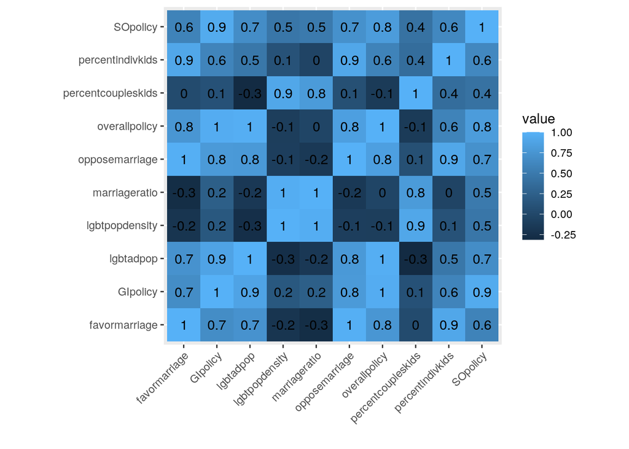

```r
lgbtstatfull %>% select_if(is.numeric) %>% cor %>% as.data.frame %>%
    rownames_to_column %>% pivot_longer(-1) %>% ggplot(aes(rowname,
    name, fill = value)) + geom_tile() + geom_text(aes(label = round(value,
    0.5))) + xlab("") + ylab("") + coord_fixed() + theme(axis.text.x = element_text(angle = 45,
    hjust = 1))
```

#### Visualizing

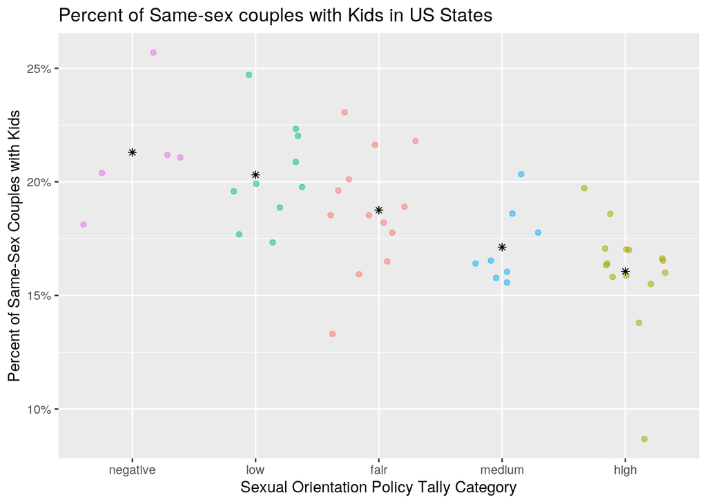

```r
lgbt %>% ggplot(aes(x = reorder(SOcategory, -percentcoupleskids),
    y = percentcoupleskids, fill = SOcategory, alpha = 0.2)) +
    geom_jitter(alpha = 0.5, aes(color = SOcategory)) + theme(legend.position = "none") +
    geom_point(stat = "summary", shape = 8, alpha = 5) + xlab("Sexual Orientation Policy Tally Category") +
    ylab("Percent of Same-Sex Couples with Kids") + scale_y_continuous(breaks = seq(0,
    30, 5), labels = c("0%", "5%", "10%", "15%", "20%", "25%",
    "30%")) + ggtitle("Percent of Same-sex couples with Kids in US States")
```

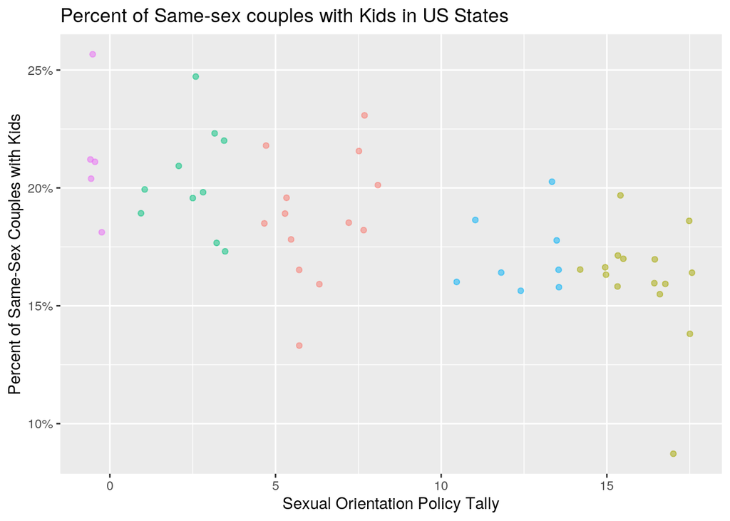

```r
lgbt %>% ggplot(aes(x = SOpolicy, y = percentcoupleskids, fill = SOcategory,
    alpha = 0.2)) + geom_jitter(alpha = 0.5, aes(color = SOcategory)) +
    theme(legend.position = "none") + xlab("Sexual Orientation Policy Tally") +
    ylab("Percent of Same-Sex Couples with Kids") + scale_y_continuous(breaks = seq(0,
    30, 5), labels = c("0%", "5%", "10%", "15%", "20%", "25%",
    "30%")) + ggtitle("Percent of Same-sex couples with Kids in US States")
```

The Sexual Orientation Policy Tally was grouped into 5 categories: High, Medium, Fair, Low, and Negative. The Percent of Same-Sex couples who have kids per state is plotted within the categories. The plot shows a trend of the lower your Policy tally category the higher the pertange of couples with kids. It is surprising to me to see more same-sex couples having kids in states with worse Sexual Orientation policies. I would expect states with worse SO policies to make it more difficult to adopt orr parent a child as an LGBT person. However, I think it might be because states that are more likely to be more rural or have a value of having more kids, arer the states that have worse laws. Would be interesting to look at statistics for straight couples and see how it compares to the SO categories.

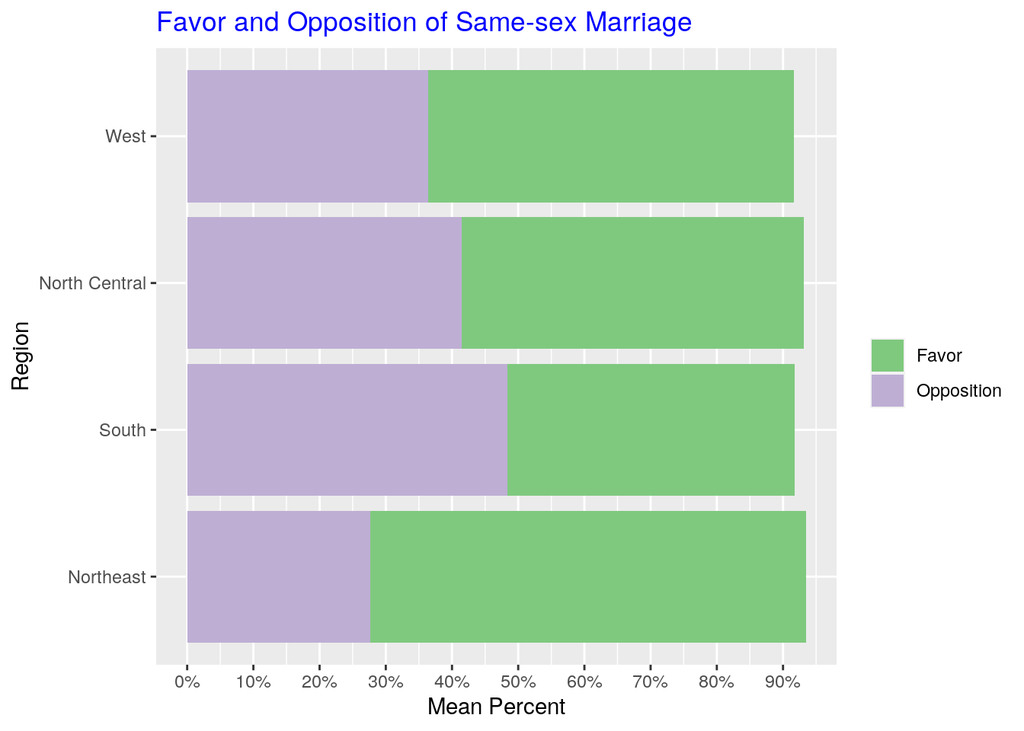

```r
plot2data <- lgbt %>% na.omit %>% group_by(state.region) %>%
    summarize(Favor = mean(favormarriage), Opposition = mean(opposemarriage)) %>%
    arrange(-Favor)

plot2data %>% pivot_longer(2:3) %>% ggplot(aes(x = state.region,
    y = value, fill = name)) + geom_col() + coord_flip() + xlab("Region") +
    ylab("Mean Percent") + theme(plot.title = element_text(colour = "Blue"),
    legend.title = element_text(colour = "white")) + ggtitle("Favor and Opposition of Same-sex Marriage") +
    scale_y_continuous(breaks = seq(0, 100, 10), labels = c("0%",
        "10%", "20%", "30%", "40%", "50%", "60%", "70%", "80%",
        "90%", "100%")) + scale_fill_brewer(palette = "Accent")
```

This plot looks at the mean percentage of people who favor same-sex marriage per region of the US in the green color, and the mean percentage of people who oppoose same-sex Marriage per region in Purple. The plot shows that the North East has the least opposition and the South has the most opposition. This is not surprising as the South is much more conservative than thee NorthEast and West regions.

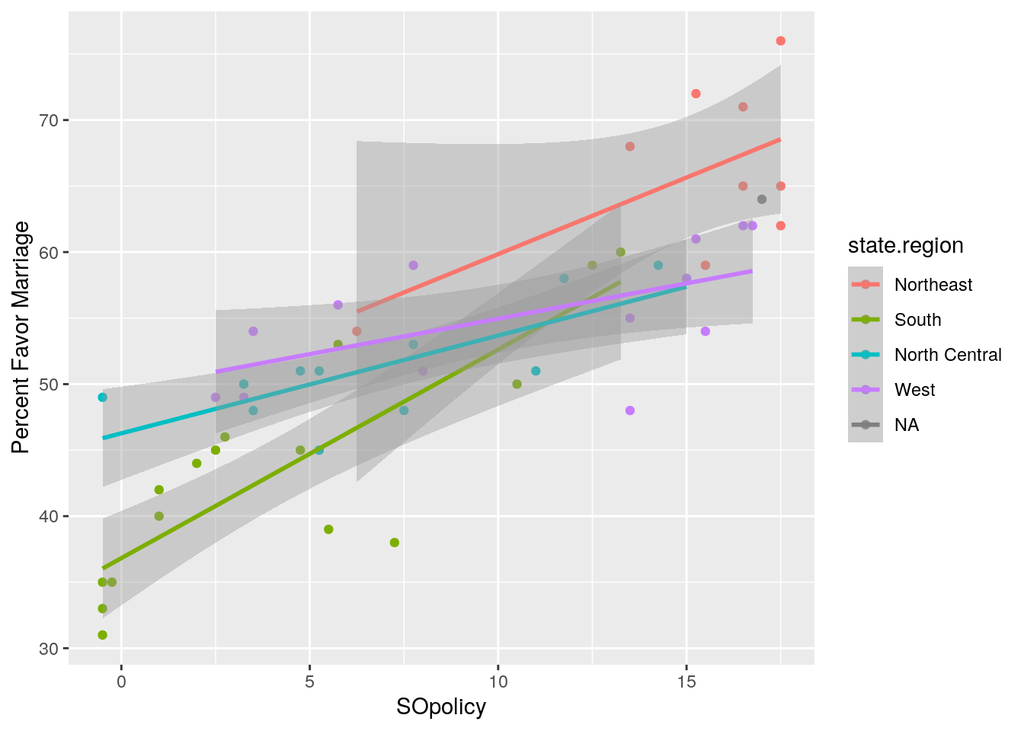

```r
lgbt %>% ggplot(aes(x = SOpolicy, y = favormarriage, col = state.region)) +
    geom_point() + ylab("Percent Favor Marriage") + geom_smooth(method = "lm")
```

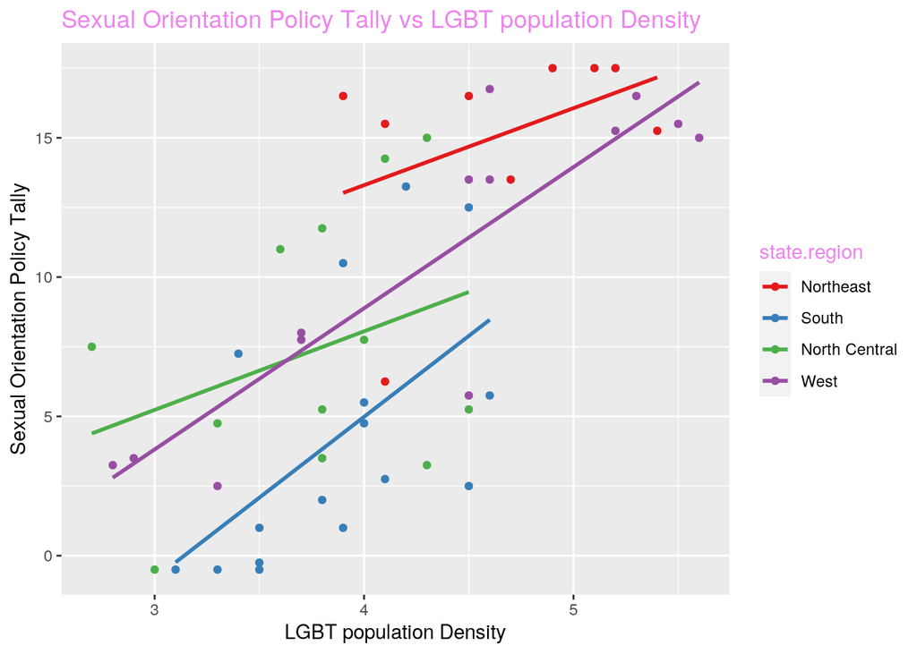

```r
lgbt %>% na.omit %>% ggplot(aes(x = lgbtpopdensity, y = SOpolicy,
    col = state.region)) + geom_point() + ylab("Sexual Orientation Policy Tally") +
    xlab("LGBT population Density") + geom_smooth(method = "lm",
    se = F) + scale_color_brewer(palette = "Set1") + ggtitle("Sexual Orientation Policy Tally vs LGBT population Density") +
    theme(plot.title = element_text(colour = "violet"), legend.title = element_text(colour = "violet"))
```

Plot 3 demonstrate the Sexual Orientation Policy Tally versus the LGBT population density. This plot shows that the policy tally increases as population density increases. This trend is also seen when grouped by regions.

#### Concluding Remarks

This was really fun and loved playing around with combining different variable to create different plots, and tables.